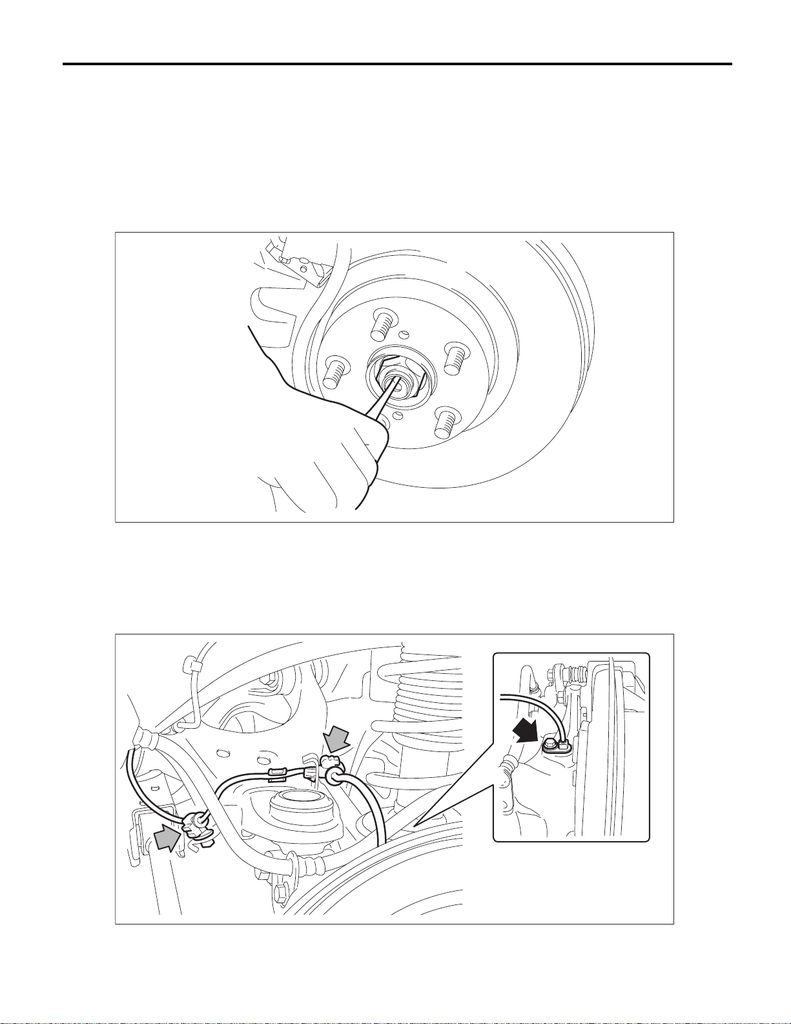

DS-40

Rear Hub Unit Bearing

DRIVE SHAFT SYSTEM

6. Rear Hub Unit Bearing

A: REMOVAL

1) Lift up the vehicle, and then remove the rear wheels.

2) Remove the nut - axle.

CAUTION:

Do not loosen the nut - axle while the rear axle is loaded. Doing so may damage the hub unit COMPL.

(1) Lift the crimped section of the nut - axle.

(2) Remove the nut - axle using a socket wrench while depressing the brake pedal.

3) Remove the rear ABS wheel speed sensor.

(1) Remove the bolts, and remove the rear ABS wheel speed sensor.

(2) Remove the rear ABS wheel speed sensor harness from the upper arm.

CAUTION:

• Be careful not to damage the sensor.

• Do not apply excessive force to the sensor harness.

DS-00486

RS-00414

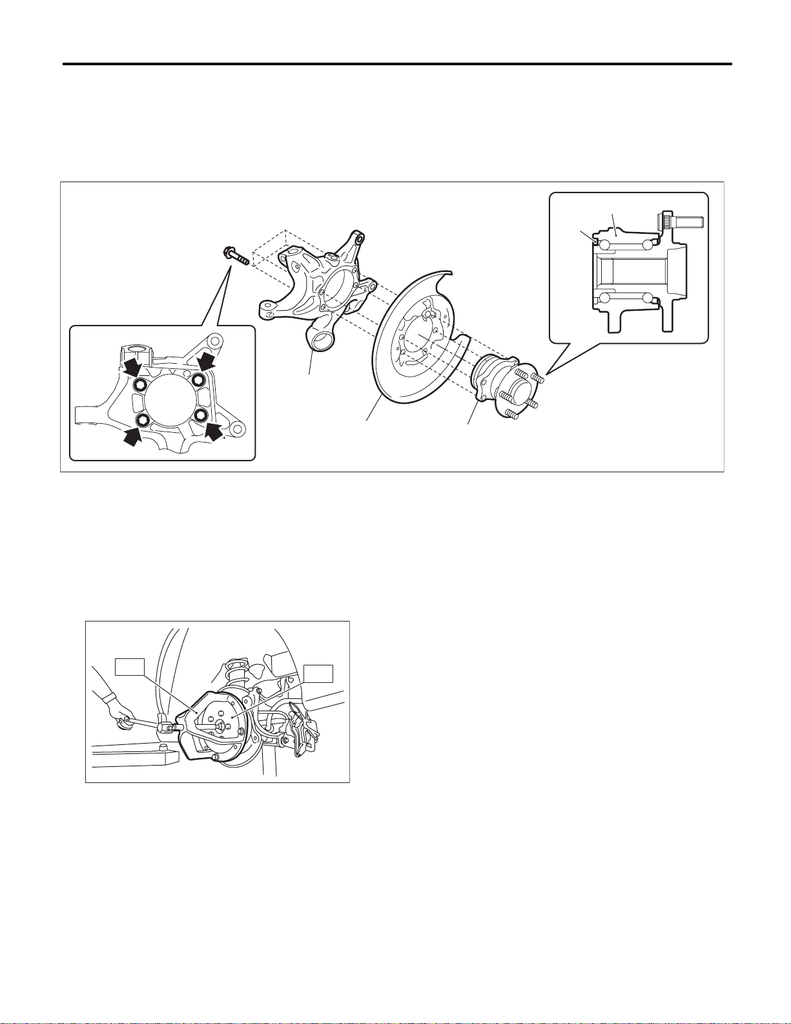

DS-41

Rear Hub Unit Bearing

DRIVE SHAFT SYSTEM

4) Remove the disc brake assembly. <Ref. to BR-43, REMOVAL, Rear Disc Brake Assembly.>

5) Remove the rear disc rotor. <Ref. to BR-39, REMOVAL, Rear Disc Rotor.>

6) Remove the hub unit COMPL - rear axle.

CAUTION:

• Be careful not to damage the magnetic encoder.

• Do not get closer the tool which charged magnetism to magnetic encoder.

NOTE:

If it is hard to remove, use the ST.

Preparation tool:

ST1: AXLE SHAFT PULLER (926470000)

ST2: AXLE SHAFT PULLER PLATE (28099PA110)

(a) Housing ASSY - rear axle (c) Hub unit COMPL - rear axle (d) Magnetic encoder

(b) Back plate - rear brake

DS-00575

(c)

(d)

(c)

(b)

(a)

DS-00122

ST2

ST1

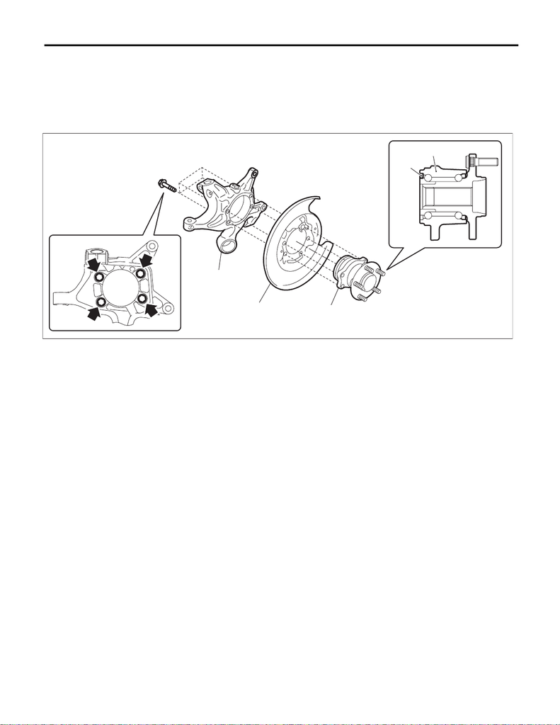

DS-42

Rear Hub Unit Bearing

DRIVE SHAFT SYSTEM

B: INSTALLATION

1) Place the back plate - rear brake between the housing assembly - rear axle and the hub unit COMPL - rear

axle, and tighten the bolt.

CAUTION:

• Do not get closer the tool which charged magnetism to magnetic encoder.

• Be careful not to damage the magnetic encoder.

Tightening torque:

65 N·m (6.6 kgf-m, 47.9 ft-lb)

2) Install the rear drive shaft assembly.

CAUTION:

Do not hammer the drive shaft assembly when installing.

(1) Insert the drive shaft assembly into the hub spline, and pull it into the specified position.

(2) Tighten the new nut - axle temporarily.

3) Install the disc rotor to the hub unit COMPL - rear axle.

4) Install the caliper body assembly to the housing assembly - rear axle.

Tightening torque:

STI model: 65 N·m (6.6 kgf-m, 47.9 ft-lb)

Except for STI model: 66 N·m (6.7 kgf-m, 48.7 ft-lb)

5) Install the brake hose bracket.

Tightening torque:

33 N·m (3.4 kgf-m, 24.3 ft-lb)

6) Install the rear ABS wheel speed sensor.

Tightening torque:

7.5 N·m (0.8 kgf-m, 5.5 ft-lb)

(a) Housing ASSY - rear axle (c) Hub unit COMPL - rear axle (d) Magnetic encoder

(b) Back plate - rear brake

DS-00575

(c)

(d)

(c)

(b)

(a)

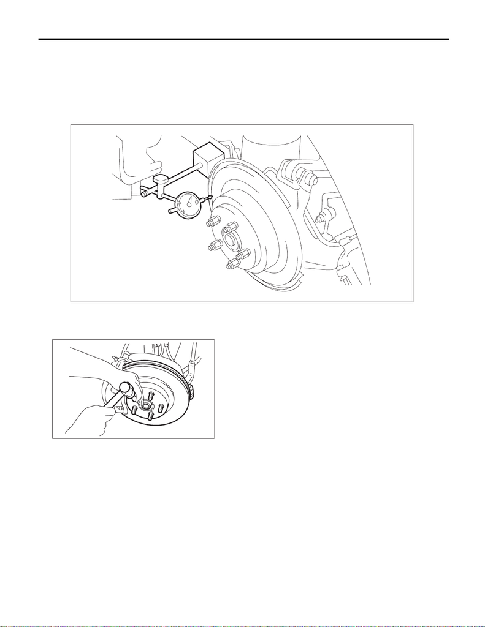

DS-43

Rear Hub Unit Bearing

DRIVE SHAFT SYSTEM

7) While depressing the brake pedal, tighten new nuts - axle to the specified torque.

CAUTION:

Do not load the rear axle before tightening the nut - axle. Doing so may damage the hub unit COMPL.

Tightening torque:

190 N·m (19.4 kgf-m, 140.1 ft-lb)

8) Inspect the lean of axis direction using a dial gauge. Replace the hub unit COMPL - rear axle if the play

exceeds the limit.

Service limit:

Maximum: 0.05 mm (0.0020 in)

9) After tightening the nut - axle, lock it securely.

BR-00822

DS-00048

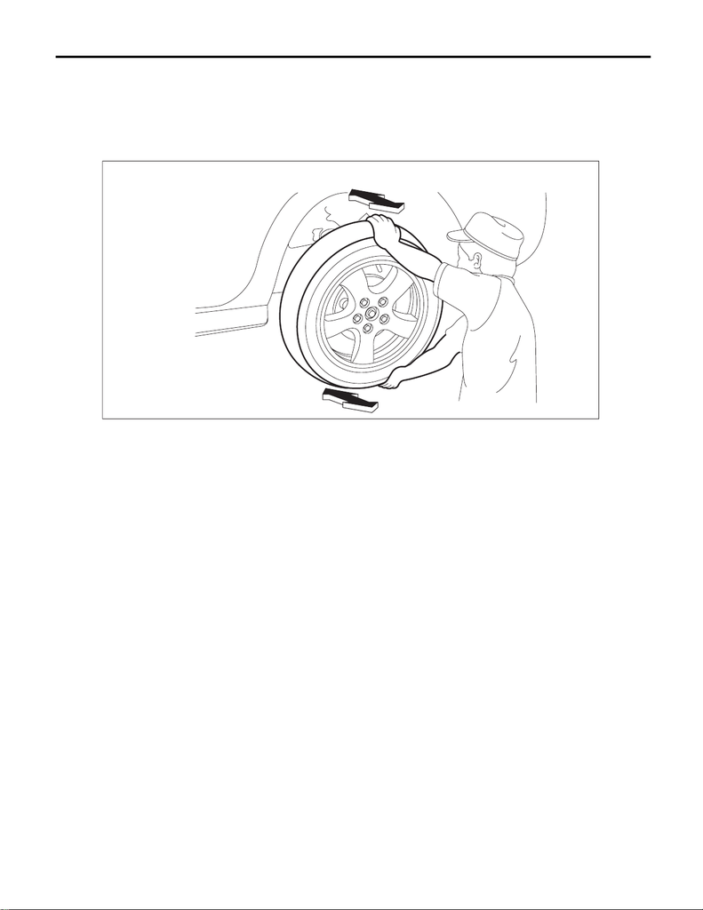

DS-44

Rear Hub Unit Bearing

DRIVE SHAFT SYSTEM

10) Install the rear wheels, and perform the following inspections.

Tightening torque:

120 N·m (12.2 kgf-m, 88.5 ft-lb)

1. Check the wheels for smooth rotation.

2. Check that there is no play by moving the upper and lower portions of rear tire in an axial direction with the

brake pedal released.

• Play exists → Check the hub unit COMPL - rear axle. <Ref. to DS-47, INSPECTION, Rear Hub Unit

Bearing.>

DS-00609

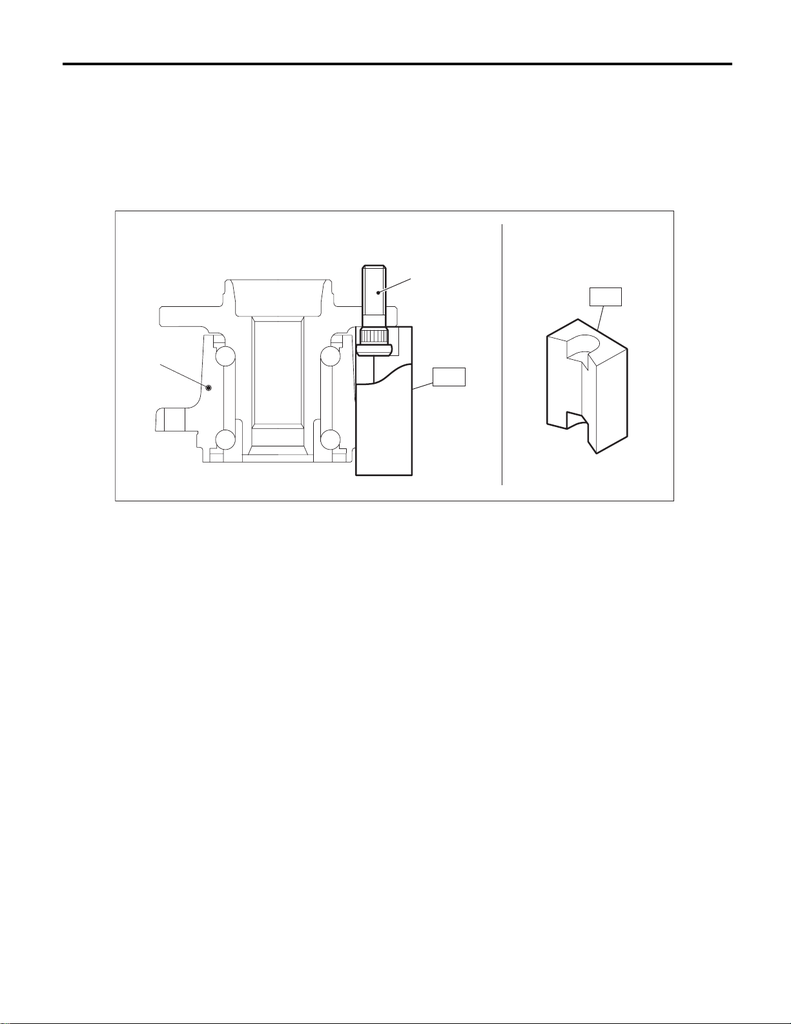

DS-45

Rear Hub Unit Bearing

DRIVE SHAFT SYSTEM

C: DISASSEMBLY

Using the ST or a hydraulic press, push out the bolt - hub (b) from the hub unit COMPL - rear axle (a).

CAUTION:

• Be careful not to hammer the bolts - hub. This may deform the hub unit COMPL.

• Do not reuse the bolt - hub.

Preparation tool:

ST: HUB STAND (28399AG000)

NOTE:

Since the hub unit COMPL - rear axle cannot be disassembled, only bolts - hub can be removed.

DS-00500

ST

ST

(a)

(a)

(b)

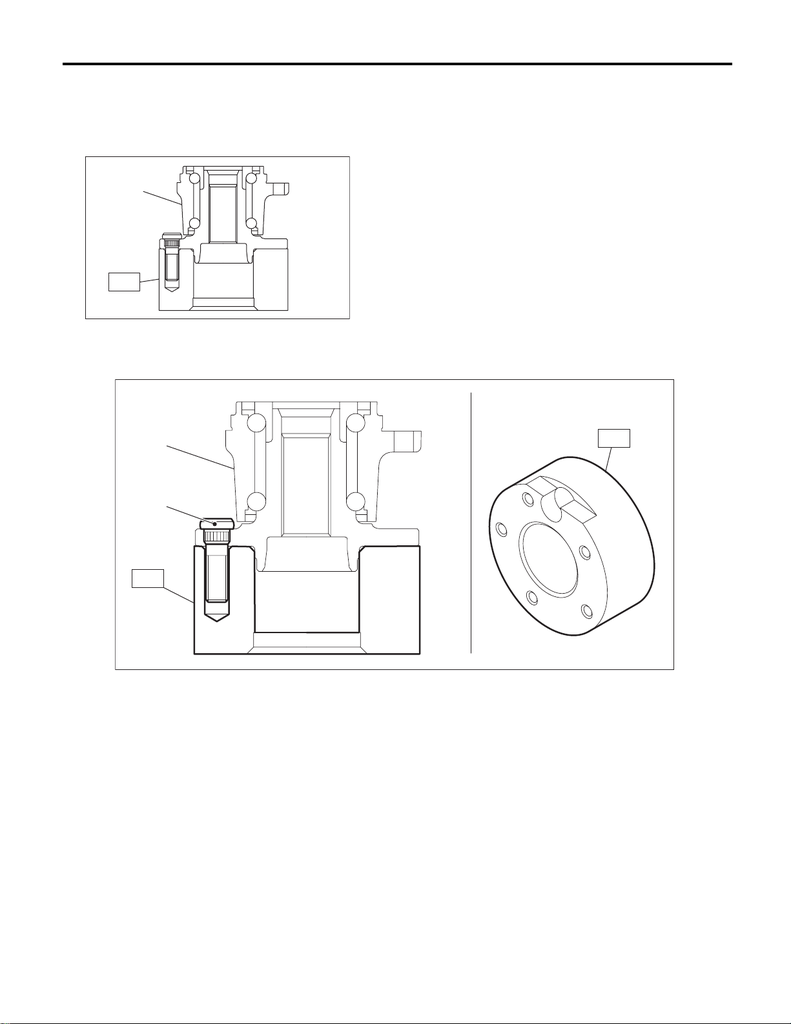

DS-46

Rear Hub Unit Bearing

DRIVE SHAFT SYSTEM

D: ASSEMBLY

1) Install the hub unit COMPL - rear axle to the ST securely.

Preparation tool:

ST: HUB STAND (28099PA080)

2) Using a press, press new bolts - hub (b) until their seating surfaces contact the hub unit COMPL - rear axle (a).

NOTE:

Use the 12 mm (0.47 in) dia. holes in the HUB STAND to prevent bolts from tilting.

DS-00255

ST

(1)

(1) Hub unit COMPL - rear axle

DS-00501

ST

(a)

ST

(b)

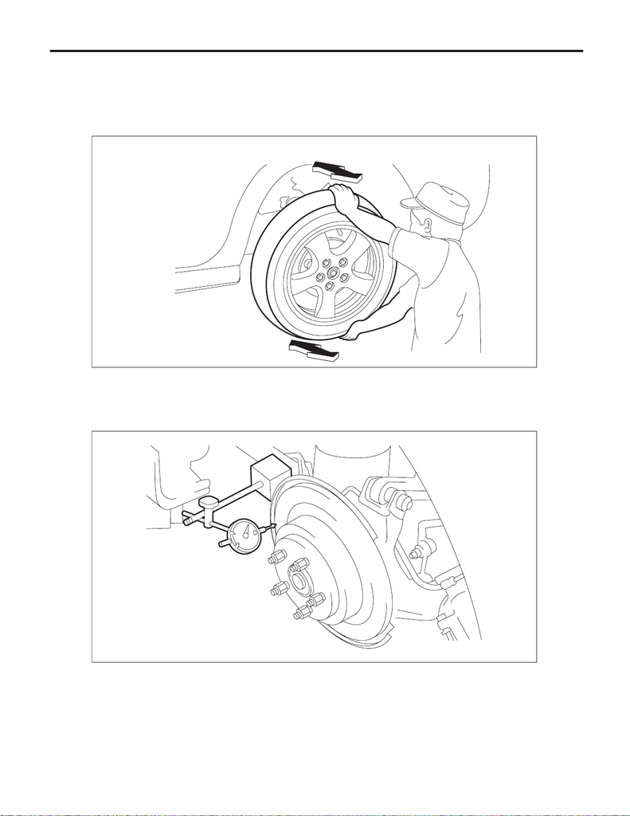

DS-47

Rear Hub Unit Bearing

DRIVE SHAFT SYSTEM

E: INSPECTION

1) Moving the rear tire up and down by hand, check there is no backlash in bearing, and check the wheel ro-

tates smoothly.

CAUTION:

If there is any fault in the bearing, replace the hub unit COMPL - rear axle.

2) Inspect the lean of axis direction using a dial gauge. Replace the hub unit COMPL - rear axle if the play

exceeds the limit.

Service limit:

Maximum: 0.05 mm (0.0020 in)

DS-00609

BR-00822